# ME613A - Análise de Regressão

Profa. Tatiana Benaglia

Atividade Prática 01 - 2S2025 - 27/08/2025

## Introdução

Uma empresa de pesquisa (Last Resource, Inc., Bellefonte, PA) fez um estudo para verificar qual a relação entre a idade do motorista e a distância que ele consegue enxergar bem.

Foi coletada uma amostra de $n = 30$ motoristas, na qual perguntaram a idade do motorista e mediram a distância (em pés) que eles conseguiam enxergar bem um sinal de trânsito. Esses dados estão disponíveis no Moodle, no arquivo chamado *signdist.txt*.

## Atividade

1. Leia o conjunto de dados no R e faça um gráfico de dispersão para visualizar a relação entre a idade (variável preditora $X$) e distância (variável resposta $Y$).

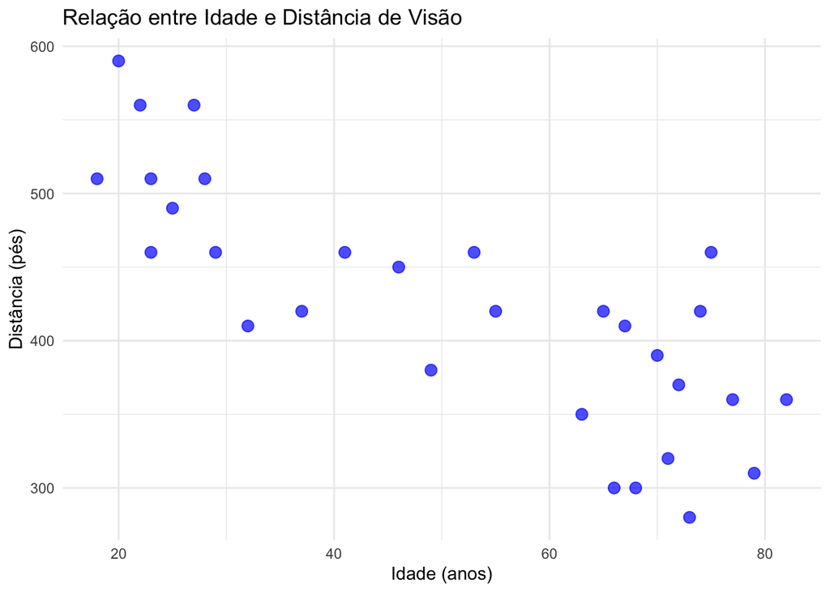

```r
dados <- read.table("signdist.txt", header = TRUE)
#view(dados)
#head(dados)

## Y (distancia) e a minha variavel resposta  e X (idade) e minha variavel preditora que e utiizada para prever a distancia


#Criando o grafico de dispersao
ggplot(dados, aes(x = Age, y = Distance)) +
  geom_point(color = "blue", size = 3, alpha = 0.7) +
  labs(title = "Relação entre Idade e Distância de Visão",
       x = "Idade (anos)",
       y = "Distância (pés)") +
  theme_minimal()
```

2. Calcule as estatísticas descritivas das variáveis e também o coeficiente de correlação entre elas.

```r
dados %>%
    summary() %>%
    kable(caption = "Table1a 1. Estatisticas Sumarias") %>%
    kable_styling(full_width = F, position = "center")
```

Table1a 1. Estatisticas Sumarias

|  | Age | Distance |
| --- | --- | --- |
|  | Min. :18.00 | Min. :280.0 |
|  | 1st Qu.:28.25 | 1st Qu.:362.5 |
|  | Median :54.00 | Median :420.0 |
|  | Mean :51.00 | Mean :423.3 |
|  | 3rd Qu.:70.75 | 3rd Qu.:460.0 |
|  | Max. :82.00 | Max. :590.0 |

```r
x = dados$Age
y = dados$Distance

x_barra = mean(x)
desvio_padrao_x =sd(x)
x_median = median(x)
x_variancia = var(x)

y_barra = mean(y)
desvio_padrao_y =sd(y)
y_median = median(y)
y_variancia = var(y)

correlacao = cor(x, y)
```

**Médias:**

A média de idade é **51**  
A média de distância é **423.3333333**

**Variâncias:**

A variância da idade é **474.2068966**  
A variância da distância é **6678.1609195**

**Desvio Padrão:**

O desvio padrão da idade é **21.7762921**  
O desvio padrão da distância é **81.7200154**

A **correlação** entre idade e distância é **-0.8012447**

3. Utilizando o R como uma calculadora simples, calcule as estatísticas de interesse que serão posteriormente utizadas para encontrar os estimadores de $\beta_0$ e $\beta_1$.

```r
#B0 = y_barra - B1*x_barra
#B1 = Sxy / Sxx

# Numerador e denominador de beta1
numerador <- sum((x - x_barra) * (y - y_barra))
denominador <- sum((x - x_barra)^2)

# Cálculo manual de beta1 y beta0
beta1 <- round((numerador / denominador),2)
beta0 <- round((y_barra - beta1 * x_barra),2)
```

$\beta_0$ = **576.84**  
$\beta_1$ = **-3.01**

4. Usando as estatísticas do item anterior, escreva uma função que, para um dado conjunto de dados, retorna as estimativas de $\hat \beta_0$ e $\hat \beta_1$. **Nota**: não usar a função `lm()`.
5. Ajuste o modelo de regressão linear simples utilizando a função `lm()` e compare os resultados obtidos no item 3. **Dica**: use as funções `summary()` ou `coef()` para visualizar os coeficientes estimados.
6. Apresente um gráfico de dispersão dos dados juntamente com a reta de regressão ajustada. Escreva um parágrafo com as interpretação dos parâmetros. **Nota**: utilize a função `geom_abline()`. Você não deve usar a função `geom_smooth()`.
7. Utilizando as fórmulas dadas em aula, encontre as estimativas das variâncias de $\varepsilon$, $\beta_0$ e $\beta_1$. Verifique os cálculos com os resultados apresentados na tabela dos coeficientes estimados obtida no R.
8. Encontre os intervalos de confiança de 90% para $\beta_0$ e $\beta_1$ da seguinte forma:
   1. usando as fórmulas dadas em aula
   2. usando a função `confint()`
9. Apresente um teste de hipótese para verificar se o coeficiente $\beta_1$ é nulo ou não, usando o seguinte:
   1. Teste t
   2. Teste F
10. Calcule o coeficiente de determinação $R^2$ e interprete-o.
11. Centralize a variável preditora em sua média e ajuste uma regressão simples novamente. Compare o resultado com aquele obtido no item 4.
12. Se você transformar a distância de pés para metros, como isso afeta os coeficientes da regressão? Note que 1 pé = 0,3048 metros.